# Intro to R

Day 6

Class date: 02/21/2017 Last update: 02/22/17

# 1 Libraries

```r
library(tidyverse)
```

# 2 T-tests

## 2.1 Independent samples

| Name | group | score |
| --- | --- | --- |
| John | g1 | 250 |
| Jane | g1 | 340 |
| Jimmy | g2 | 460 |
| Jessy | g2 | 200 |

Let’s turn the table into a dataframe.

```r
name1 <- c('John', 'Jane', 'Jimmy', 'Jessy')
group1 <- c('g1', 'g1', 'g2', 'g2')
score1 <- c(250, 340, 460, 200)
ind_samp <- data.frame(name = name1, group = group1, score = score1)
print(ind_samp)
```

```
##    name group score
## 1  John    g1   250
## 2  Jane    g1   340
## 3 Jimmy    g2   460
## 4 Jessy    g2   200
```

Let’s test to see if the difference between the score means of ‘g1’ and ‘g2’ is equal to 0.

```r
# t-test: independent 2-group
t.test(score ~ group, data = ind_samp)
```

```
##
##  Welch Two Sample t-test
##
## data:  score by group
## t = -0.25442, df = 1.2363, p-value = 0.8349
## alternative hypothesis: true difference in means is not equal to 0
## 95 percent confidence interval:
##  -1161.468  1091.468
## sample estimates:
## mean in group g1 mean in group g2
##              295              330
```

## 2.2 Paired samples

| Name | Test1 | Test2 |
| --- | --- | --- |
| Mike | 35 | 67 |
| Melanie | 50 | 46 |
| Melissa | 90 | 86 |
| Mitchell | 78 | 91 |

Let’s turn the table into a dataframe.

```r
name2 <- c('Mike', 'Melanie', 'Melissa', 'Mitchell')
test1 <- c(35, 50, 90, 78)
test2 <- c(67, 46, 86, 91)
prd_samp <- data.frame(test1, test2)
print(prd_samp)
```

```
##   test1 test2
## 1    35    67
## 2    50    46
## 3    90    86
## 4    78    91
```

Let’s test to see if the difference between ‘test1’ and ‘test2’ is equal to 0.

```r
# t-test: paired sample
t.test(test1, test2, paired = TRUE)
```

```
##
##  Paired t-test
##
## data:  test1 and test2
## t = -1.0785, df = 3, p-value = 0.3598
## alternative hypothesis: true difference in means is not equal to 0
## 95 percent confidence interval:
##  -36.54539  18.04539
## sample estimates:
## mean of the differences
##                   -9.25
```

Recall that we can also use standard y-as-a-function-of-x syntax, but we have to convert the dataframe to long format.

```r
prd_samp_long <- tidyr::gather(prd_samp, key = test, val = score)
print(prd_samp_long)
```

```
##    test score
## 1 test1    35
## 2 test1    50
## 3 test1    90
## 4 test1    78
## 5 test2    67
## 6 test2    46
## 7 test2    86
## 8 test2    91
```

```r
# t-test: paired sample
t.test(score ~ test, data = prd_samp_long, paired = TRUE)
```

```
##
##  Paired t-test
##
## data:  score by test
## t = -1.0785, df = 3, p-value = 0.3598
## alternative hypothesis: true difference in means is not equal to 0
## 95 percent confidence interval:
##  -36.54539  18.04539
## sample estimates:
## mean of the differences
##                   -9.25
```

## 2.3 More examples

Run paired samples t-test on the iris dataset. Check the structure and pick the first 2 continuous variables.

```r
str(iris)
```

```
## 'data.frame':    150 obs. of  5 variables:
##  $ Sepal.Length: num  5.1 4.9 4.7 4.6 5 5.4 4.6 5 4.4 4.9 ...
##  $ Sepal.Width : num  3.5 3 3.2 3.1 3.6 3.9 3.4 3.4 2.9 3.1 ...
##  $ Petal.Length: num  1.4 1.4 1.3 1.5 1.4 1.7 1.4 1.5 1.4 1.5 ...
##  $ Petal.Width : num  0.2 0.2 0.2 0.2 0.2 0.4 0.3 0.2 0.2 0.1 ...
##  $ Species     : Factor w/ 3 levels "setosa","versicolor",..: 1 1 1 1 1 1 1 1 1 1 ...
```

`Sepal.Length` and `Sepal.Width` (columns 1 and 2) are both continuous. Each row represents different measures of the same flower, so a paired test is appropriate.

```r
# Paired samples t-test
t.test(iris$Sepal.Length, iris$Sepal.Width, paired = TRUE)
```

```
##
##  Paired t-test
##
## data:  iris$Sepal.Length and iris$Sepal.Width
## t = 34.815, df = 149, p-value < 2.2e-16
## alternative hypothesis: true difference in means is not equal to 0
## 95 percent confidence interval:
##  2.627874 2.944126
## sample estimates:
## mean of the differences
##                   2.786
```

It looks like the difference between the means is not equal to 0; therefore, we reject the null hypothesis. Here is a plot to visualize the result.

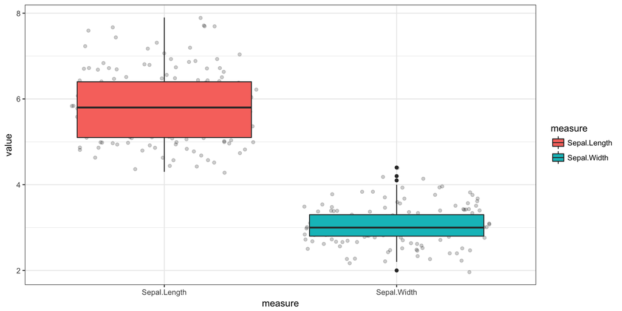

```r
iris %>%
  select(., Sepal.Length, Sepal.Width) %>%
  gather(., key = measure, val = value) %>%
  ggplot(., aes(x = measure, y = value, fill = measure)) +
  geom_jitter(alpha = 0.2) +
  geom_boxplot() +
  theme_bw()
```

This is an example of how we can write up the result for publication in a manuscript:

> The iris data were analyzed using a paired-samples t-test, with value as the dependent variable and measure (Length, Width) as a within-subjects factor. The analysis revealed that the mean between the two measures was not equal to 0 (t(149) = 34.82, p < 0.001). Specifically, sepal length (mean: 5.84, sd: 0.83) was longer than sepal width (mean: 3.06, sd: 0.44) (See Figure X). The mean of the differences was 2.79 cm with the 95% confidence interval falling between 2.63 cm and 2.94 cm.

Notice that the write-up explains what test we used, what the variables are (DV, IV) and the relevant levels, the result of the test, an explanation of the result, including directionality of the effect.

Try to do the same thing using the `Species` factor. Let’s compare the `Sepal.Width` of the `setosa` and `versicolor` species. How can we do this?

```r
str(iris)
```

```
## 'data.frame':    150 obs. of  5 variables:
##  $ Sepal.Length: num  5.1 4.9 4.7 4.6 5 5.4 4.6 5 4.4 4.9 ...
##  $ Sepal.Width : num  3.5 3 3.2 3.1 3.6 3.9 3.4 3.4 2.9 3.1 ...
##  $ Petal.Length: num  1.4 1.4 1.3 1.5 1.4 1.7 1.4 1.5 1.4 1.5 ...
##  $ Petal.Width : num  0.2 0.2 0.2 0.2 0.2 0.4 0.3 0.2 0.2 0.1 ...
##  $ Species     : Factor w/ 3 levels "setosa","versicolor",..: 1 1 1 1 1 1 1 1 1 1 ...
```

`Species` is a factor with three levels. We know that a t-test can only compare two groups, so we need to subset the dataset in order to remove the 3rd level of `Species`, `virginica`.

```r
# Remove 'virginica'
irisNoVirginica <- iris[iris$Species != "virginica", ]

# Independent samples t-test
t.test(Sepal.Width ~ Species, data = irisNoVirginica, paired = FALSE)
```

```
##
##  Welch Two Sample t-test
##
## data:  Sepal.Width by Species
## t = 9.455, df = 94.698, p-value = 2.484e-15
## alternative hypothesis: true difference in means is not equal to 0
## 95 percent confidence interval:
##  0.5198348 0.7961652
## sample estimates:
##     mean in group setosa mean in group versicolor
##                    3.428                    2.770
```

Notice that I changed paired to FALSE. Why? Is each observation coming from the same flower? Here is a visualization of the result:

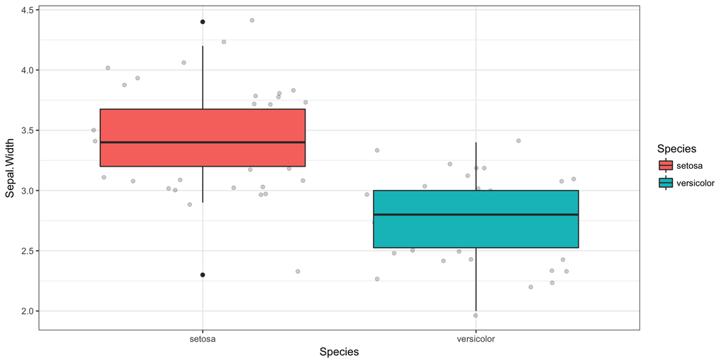

```r
ggplot(irisNoVirginica, aes(x = Species, y = Sepal.Width, fill = Species)) +
  geom_jitter(alpha = 0.2) +
  geom_boxplot() +
  theme_bw()
```

How would you write in prose the result of the test?